# Caso 04

oferta comercial: media 19, P(≤19) = 0.28 por Monte Carlo, plazo 90 % 22.8; óptimo 21

# Enunciado

Su empresa prepara la oferta para un proyecto llave en mano. El equipo técnico ha estimado para cada actividad tres duraciones (optimista, más probable y pesimista, en semanas) y el cuadro de prelaciones, que se adjuntan. Hay que escribir en la oferta **el plazo de entrega comprometido**, y de él dependen penalizaciones y bonificaciones. Antes de cerrar la oferta recibe estos mensajes.

Tabla 1: Cuadro de prelaciones y tres estimaciones de duración

| activity | predecessor | optimista | mas_probable | pesimista |
| --- | --- | --- | --- | --- |
| A | --- | 6 | 7 | 14 |
| B | --- | 1 | 6 | 11 |
| C | A,B | 1 | 4 | 7 |
| D | B | 1 | 5 | 9 |
| E | A,B | 1 | 5 | 9 |
| F | C | 2 | 4 | 12 |
| G | C,E | 1 | 3 | 5 |
| H | D,F,G | 1 | 2 | 3 |
| I | E | 1 | 4 | 13 |

> **De: Director comercial** El competidor va a ofertar 20 semanas. Con las estimaciones del equipo nos sale una duración de 19 semanas: propongo escribir **19 semanas** en la oferta, que es lo que dicen nuestros números y nos pone por delante. No veo por qué añadir colchón.

> **De: Jefe de producción** Las estimaciones son razonables salvo la de F: la duración pesimista (12) se queda corta, yo pondría al menos 14. Y recordad que las medias no se suman alegremente: si varias cosas van regular a la vez, el proyecto se va mucho más de lo que dice la ruta crítica.

> **De: Cliente** Las condiciones del contrato: penalización de **4 k€ por semana** de retraso sobre el plazo ofertado y bonificación de **1 k€ por semana** de adelanto. Valoraremos el plazo ofertado: cada semana por encima de 20 resta puntos en la adjudicación.

> **De: Asesoría jurídica** No podemos firmar un plazo que no estemos en condiciones de cumplir con alta probabilidad: pedimos que el plazo comprometido se cumpla **al menos en el 90 % de los escenarios**. Si el plazo es menor, que quede documentado quién asume el riesgo.

> **De: Dirección financiera** Ofertar más plazo tiene un coste comercial: estimamos que cada semana por encima de las 20 del competidor equivale a 2 k€ de descuento en precio para seguir siendo competitivos. Pero las penalizaciones se pagan en efectivo. Quiero el plazo que minimiza el coste esperado total.

Responda a las preguntas siguientes **antes** de decidir. En la penúltima se le pide la decisión y cómo la comunicaría a cada uno de los implicados (director comercial, jefe de producción, cliente, asesoría jurídica, dirección financiera).

1. Con el método PERT (media y varianza de cada actividad a partir de las tres estimaciones) calcule la duración esperada, la desviación típica del camino crítico, la probabilidad de terminar en 19 semanas y el plazo que se cumpliría con el 90 % de probabilidad.

2. Simule el proyecto por Monte Carlo (20000 réplicas, distribución PERT por actividad). Compare con lo anterior: probabilidad de terminar en 19 semanas, plazo al 90 % e índice de criticidad de cada actividad. ¿Por qué no coinciden? ¿Qué actividad no crítica merece vigilancia?

3. Incorpore la observación del jefe de producción (pesimista de F = 14). ¿Cuánto cambian la media, la probabilidad y el plazo al 90 %?

4. Con las réplicas de Monte Carlo, calcule para cada plazo candidato el coste esperado total: descuento comercial por semana ofertada por encima de 20, penalización esperada y bonificación esperada. ¿Qué plazo minimiza el coste esperado? ¿Cumple la condición de asesoría jurídica? Si no, ¿cuánto cuesta cumplirla?

5. Decida el plazo que escribe en la oferta y redacte en tres o cuatro líneas la respuesta a cada implicado.

6. ¿Qué lecciones generales saca sobre prometer plazos a partir de estimaciones (medias, colchones, actividades casi críticas, seguimiento)?

# Resolución

## Apartado 1

1. Con el método PERT (media y varianza de cada actividad a partir de las tres estimaciones) calcule la duración esperada, la desviación típica del camino crítico, la probabilidad de terminar en 19 semanas y el plazo que se cumpliría con el 90 % de probabilidad.

Tabla 2: Media y varianza PERT de cada actividad; calendario

|  | D = (a + 4m + b)/6 | σ² = ((b − a)/6)² |
| --- | --- | --- |
| A | (6 + 4·7 + 14)/6 = 8.00 | ((14 − 6)/6)² = 1.778 |
| B | (1 + 4·6 + 11)/6 = 6.00 | ((11 − 1)/6)² = 2.778 |
| C | (1 + 4·4 + 7)/6 = 4.00 | ((7 − 1)/6)² = 1.000 |
| D | (1 + 4·5 + 9)/6 = 5.00 | ((9 − 1)/6)² = 1.778 |
| E | (1 + 4·5 + 9)/6 = 5.00 | ((9 − 1)/6)² = 1.778 |
| F | (2 + 4·4 + 12)/6 = 5.00 | ((12 − 2)/6)² = 2.778 |
| G | (1 + 4·3 + 5)/6 = 3.00 | ((5 − 1)/6)² = 0.444 |
| H | (1 + 4·2 + 3)/6 = 2.00 | ((3 − 1)/6)² = 0.111 |
| I | (1 + 4·4 + 13)/6 = 5.00 | ((13 − 1)/6)² = 4.000 |

[figure not shown]

ninguna celda (0 de 72)

[figure not shown]

Haz clic en un número de la tabla para ver cómo se calcula.

👆 **Interactivo:** haz clic en cualquier celda de la tabla para ver cómo se calcula (otro clic la deselecciona), o usa los botones y las flechas del teclado.

| Actividad | Duración | Inicio más temprano | Fin más temprano | Inicio más tardío | Fin más tardío | H total | H libre | H independiente |
| --- | --- | --- | --- | --- | --- | --- | --- | --- |
| A | 8 | 0 | 8 | 0 | 8 | 0 | 0 | 0 |
| B | 6 | 0 | 6 | 2 | 8 | 2 | 0 | 0 |
| C | 4 | 8 | 12 | 8 | 12 | 0 | 0 | 0 |
| D | 5 | 6 | 11 | 12 | 17 | 6 | 6 | 4 |
| E | 5 | 8 | 13 | 9 | 14 | 1 | 0 | 0 |
| F | 5 | 12 | 17 | 12 | 17 | 0 | 0 | 0 |
| G | 3 | 13 | 16 | 14 | 17 | 1 | 1 | 0 |
| H | 2 | 17 | 19 | 17 | 19 | 0 | 0 | 0 |
| I | 5 | 13 | 18 | 14 | 19 | 1 | 1 | 0 |

Cálculo de los tiempos tempranos y tardíos de los sucesos y de las holguras totales paso a paso. El primer paso muestra el grafo resuelto; a partir del siguiente se calcula desde el principio (avance con los botones):

[figure not shown]

paso 0 de 30

[figure not shown]

Figura 1: Grafo PERT con las duraciones medias y el camino crítico

Duración esperada: A–C–F–H = 8 + 4 + 5 + 2 = 19 semanas. Desviación típica del camino crítico (raíz de la suma de las varianzas de sus actividades): σ = √(1.778 + 1.000 + 2.778 + 0.111) = √5.667 = **2.380** semanas.

Con T ~ N(19; 2.380):

- P(T ≤ 19), con T ~ N(μ = 19; σ = 2.380): `=DISTR.NORM.N(19; 19; 2,3805; VERDADERO)` = **0.5000** (50.0%): la media se cumple la mitad de las veces.

- Plazo al 90 %: t tal que P(T ≤ t) = 0.9, con T ~ N(μ = 19; σ = 2.380): `=INV.NORM(0,9; 19; 2,3805)` = **22.05** semanas.

**Respuesta:** duración esperada 19 semanas, σ = 2.38 semanas, P(T ≤ 19) = 0.50 y plazo al 90 % de 22.1 semanas.

## Apartado 2

2. Simule el proyecto por Monte Carlo (20000 réplicas, distribución PERT por actividad). Compare con lo anterior: probabilidad de terminar en 19 semanas, plazo al 90 % e índice de criticidad de cada actividad. ¿Por qué no coinciden? ¿Qué actividad no crítica merece vigilancia?

|  | mean | std | q05 | q50 | q95 | min | max |
| --- | --- | --- | --- | --- | --- | --- | --- |
| τ | 20.22 | 2.0 | 17.05 | 20.14 | 23.63 | 14.18 | 29.03 |

|  | A | B | C | D | E | F | G | H | I |
| --- | --- | --- | --- | --- | --- | --- | --- | --- | --- |
| criticidad (%) | 83.5 | 16.5 | 54.0 | 0.1 | 45.9 | 51.4 | 20.0 | 71.5 | 28.5 |
| holgura total | 0.0 | 2.0 | 0.0 | 6.0 | 1.0 | 0.0 | 1.0 | 0.0 | 1.0 |

Monte Carlo: media 20.22, desviación típica 2.00; P(T ≤ 19) = **0.28** (PERT decía 0.50); plazo al 90 %: **22.8** semanas (PERT decía 22.1).

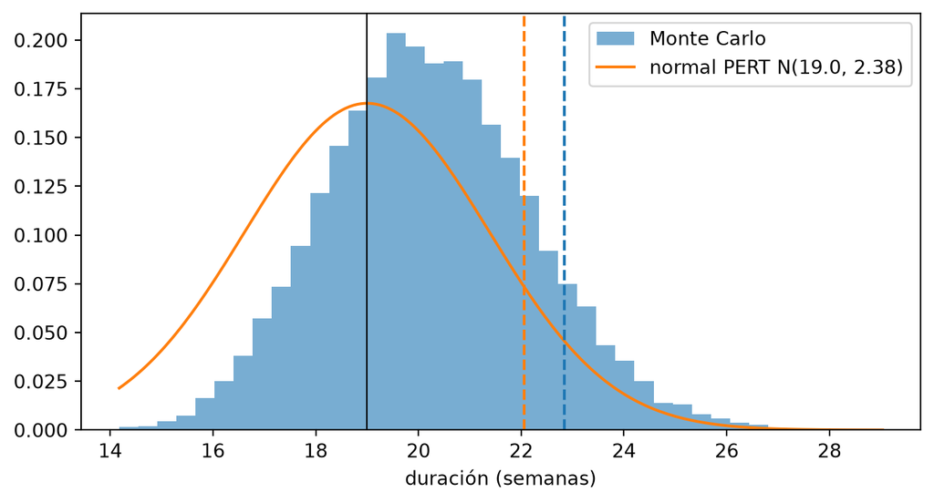

Figura 2: Distribución simulada de la duración y los dos plazos al 90 %

En Monte Carlo cada réplica sortea la duración de cada actividad con su distribución PERT y calcula la duración del proyecto (la ruta más larga de esa réplica); P(T ≤ 19) es la proporción de las 20000 réplicas que terminan en 19 semanas o menos (5564 / 20000 = 0.28), el plazo al 90 % es el percentil 90 de las duraciones simuladas y el índice de criticidad de una actividad es el porcentaje de réplicas en las que está en la ruta más larga.

La media PERT (19) subestima la duración y la normal del camino crítico subestima la cola derecha: en las réplicas hay otras rutas (la segunda dura 18 en media) que en bastantes escenarios se convierten en la más larga. Es el *sesgo de fusión* (merge bias): el máximo de varias variables aleatorias tiene media mayor que el mayor de sus medias. Por eso P(T ≤ 19) baja del 0.50 al 0.28 y el plazo al 90 % sube de 22.1 a 22.8. La actividad no crítica con más criticidad es **E** (46% de las réplicas en la ruta más larga, holgura 1): el análisis determinista la da por holgada y conviene vigilarla como si fuera crítica.

**Respuesta:** por Monte Carlo, P(T ≤ 19) = 0.28 (PERT: 0.50) y plazo al 90 % = 22.8 semanas (PERT: 22.1); no coinciden por el sesgo de fusión, que el método PERT ignora al mirar sólo el camino crítico. La actividad no crítica que hay que vigilar es E.

## Apartado 3

3. Incorpore la observación del jefe de producción (pesimista de F = 14). ¿Cuánto cambian la media, la probabilidad y el plazo al 90 %?

|  | estimaciones del equipo | pesimista de F + 2 |
| --- | --- | --- |
| media PERT | 19.00 | 19.33 |
| σ PERT | 2.38 | 2.62 |
| P(T ≤ 19) PERT | 0.50 | 0.45 |
| plazo 90 % PERT | 22.05 | 22.70 |
| P(T ≤ 19) MC | 0.28 | 0.25 |
| plazo 90 % MC | 22.85 | 23.26 |

Añadir dos semanas a la estimación pesimista de F sube su media en 2/6 = 0.33 semanas ((2 + 4·4 + 14)/6 = 5.33) y su varianza de 2.778 a ((14 − 2)/6)² = 4.000.

**Respuesta:** la duración esperada pasa de 19 a 19.33 semanas (+0.33); P(T ≤ 19) pasa de 0.50 a 0.45 con PERT y de 0.28 a 0.25 con Monte Carlo; el plazo al 90 % sube de 22.05 a 22.70 con PERT (+0.65) y de 22.85 a 23.26 con Monte Carlo (+0.41 semanas). El efecto es moderado pero va en la misma dirección: cuanto más incierta la actividad crítica, más colchón hace falta para la misma probabilidad. Y es información que el equipo de producción tenía y la oferta no.

## Apartado 4

4. Con las réplicas de Monte Carlo, calcule para cada plazo candidato el coste esperado total: descuento comercial por semana ofertada por encima de 20, penalización esperada y bonificación esperada. ¿Qué plazo minimiza el coste esperado? ¿Cumple la condición de asesoría jurídica? Si no, ¿cuánto cuesta cumplirla?

Tabla 3: Coste esperado (k€) según el plazo ofertado, con las réplicas de Monte Carlo

| plazo ofertado | P(cumplir) | penalización esperada | bonificación esperada | descuento comercial | coste esperado total |
| --- | --- | --- | --- | --- | --- |
| 18 | 0.13 | 9.36 | 0.12 | 0 | 9.25 |
| 19 | 0.28 | 6.16 | 0.32 | 0 | 5.85 |
| 20 | 0.47 | 3.65 | 0.69 | 0 | 2.96 |
| 21 | 0.66 | 1.92 | 1.26 | 2 | 2.66 |
| 22 | 0.81 | 0.89 | 2.00 | 4 | 2.89 |
| 23 | 0.91 | 0.36 | 2.87 | 6 | 3.50 |
| 24 | 0.97 | 0.13 | 3.81 | 8 | 4.32 |
| 25 | 0.99 | 0.04 | 4.79 | 10 | 5.26 |
| 26 | 1.00 | 0.01 | 5.78 | 12 | 6.23 |

Para un plazo ofertado D, con las 20000 réplicas τ de la duración (descuento comercial, penalización esperada y bonificación esperada): coste esperado = 2 × máx(0, D − 20) + 4 × media(máx(0, τ − D)) − 1 × media(máx(0, D − τ)). Para D = 21:

- descuento = 2 × máx(0, 21 − 20) = 2.00 k€

- penalización esperada = 4 × 0.480 = 1.92 k€

- bonificación esperada = 1 × 1.255 = 1.26 k€

- coste esperado = 2.00 + 1.92 − 1.26 = **2.66 k€**

**Respuesta:** el plazo que minimiza el coste esperado es **21 semanas** (P(cumplir) = 0.66), que no cumple la condición de asesoría jurídica (0.90). El primer plazo que la cumple es **23 semanas** (percentil 90 de las réplicas, 22.85, redondeado hacia arriba; P(cumplir) = 0.91), con coste esperado 3.50 k€: cumplirla cuesta 3.50 − 2.66 = **0.83 k€** esperados.

Prometer 19 semanas (lo que pide el director comercial) tiene un coste esperado de 5.8 k€ y se cumple el 28% de las veces; el óptimo económico es 21 (2.7 k€, P = 0.66) y el plazo «jurídico» 23 (3.5 k€). La penalización esperada decrece con el plazo ofertado y el descuento comercial crece 2 k€ por semana: el óptimo está donde la penalización marginal evitada iguala el descuento marginal. La condición del 90 % es una preferencia por el riesgo, no un óptimo en media: su coste es la diferencia entre las dos filas, y conviene que quien la impone lo sepa.

## Apartado 5

5. Decida el plazo que escribe en la oferta y redacte en tres o cuatro líneas la respuesta a cada implicado.

Una decisión defendible: ofertar **23 semanas**, el plazo al 90 %: la diferencia de coste esperado con el óptimo (0.8 k€) es pequeña frente al riesgo reputacional de incumplir, y evita la discusión interna. En ningún caso 19: es la media, y la media se incumple la mitad de las veces en el mejor de los casos (aquí, el 72%). Mensajes:

- *Director comercial:* «19 semanas es la duración media, no un plazo: se incumpliría el 72% de las veces y cada semana cuesta 4 k€. Propongo 23; el coste esperado total es 3.5 k€ frente a 5.8 con 19.»
- *Jefe de producción:* «Incorporada tu estimación de F; sube el plazo al 90 % en 0.4 semanas. Durante la ejecución vigilaremos F y también E, que aparece crítica en el 46% de los escenarios.»
- *Cliente:* «Plazo ofertado: 23 semanas, con las penalizaciones y bonificaciones acordadas.»
- *Asesoría jurídica:* «El plazo ofertado se cumple en el 91% de los escenarios simulados.»
- *Dirección financiera:* «Coste esperado por plazo adjunto; el mínimo es 21 semanas (2.7 k€) y el plazo al 90 % cuesta 0.8 k€ más en media. La propuesta es 23.»

## Apartado 6

6. ¿Qué lecciones generales saca sobre prometer plazos a partir de estimaciones (medias, colchones, actividades casi críticas, seguimiento)?

- La duración media del camino crítico no es un plazo: se cumple la mitad de las veces como mucho, y menos cuando hay rutas casi críticas (sesgo de fusión). Un plazo se promete con una probabilidad explícita.
- El colchón tiene un precio (descuento, competitividad) y la falta de colchón también (penalización esperada); la decisión es económica y se puede calcular con las réplicas.
- Las actividades casi críticas con mucha varianza son las que convierten el plan en papel mojado: el índice de criticidad dice cuáles vigilar, cosa que el análisis determinista no puede.
- La información del jefe de producción debía haber entrado en las estimaciones antes de calcular nada: estimar es un proceso de equipo, no una hoja que rellena uno.